# Assignment 4

Author: Carter Rhea

```python
import numpy as np
from math import e
from matplotlib import pyplot as plt
from matplotlib.pyplot import figure, plot, semilogx, semilogy, loglog, title

%matplotlib inline
```

## Problem 1:

Consider the goal of approximating $I = \int_0^1 f(x)dx$ with three evaluations of the function f, by

$$c_0f(0) + c_1f(1/2) + c_2f(1)$$

Determine the coefficients that give the highest possible degree of precision.

Then rescale this formula to give an approximation $$\int_a^b f(x) dx \approx [C_0f(a)+C_1f((a+b)/2)+C_2f(b)] (b-a) $$ What is its degree of precision? Do you recognize this result?

First I will find the coefficient $c_0,c_1,$ and $c_2$.

$$\underline{n=0} \rightarrow f(x)=1 \rightarrow \int_0^1 1 dx = 1 = c_0+c_1+c_2$$$$\underline{n=1} \rightarrow f(x)=x \rightarrow \int_0^1 x dx = \frac{1}{2} = \frac{1}{2}c_1+c_2$$$$\underline{n=2} \rightarrow f(x)=x^2 \rightarrow \int_0^1 x^2 dx = \frac{1}{3} = \frac{1}{4}c_1+c_2$$

So now we can solve for our coefficients. $$1 = c_0+c_1+c_2$$

$$\frac{1}{2} = \frac{1}{2}c_1+c_2$$$$\frac{1}{3} = \frac{1}{4}c_1+c_2$$

Solving these equations gives $$c_0=\frac{1}{6},c_1=\frac{2}{3},c_2=\frac{1}{6} $$ Hence we can check if this works for $n>2$ to get the exact degree of precision. $$\underline{n=3} \rightarrow f(x)=x^3 \rightarrow \int_0^1 x^3 dx = \frac{1}{4} = \frac{1}{8}c_1+c_2$$ Substituting in our coefficient values into $\frac{1}{4} = \frac{1}{8}c_1+c_2$ we get $$\frac{1}{4} = \frac{1}{8}\frac{4}{6}+\frac{1}{6}=\frac{1}{4} $$ Thus it has at least a degree of precision 3. Now to check for DoP 4. $$\underline{n=4} \rightarrow f(x)=x^4 \rightarrow \int_0^1 x^4 dx = \frac{1}{5} = \frac{1}{16}c_1+c_2$$

Substituting in our coefficient values into $\frac{1}{5} = \frac{1}{16}c_1+c_2$ we get $$\frac{1}{5} = \frac{1}{16}\frac{4/6}+\frac{1}{6} = \frac{5}{24} $$ Hence it does not work for n=4.

Therefore our degree of precision is 3!

Now to rescale to get an approximation for $$\int_a^b f(x) dx \approx [C_0f(a)+C_1f((a+b)/2)+C_2f(b)] (b-a) $$

## Problem 2:

For the following data, find:

(a) A linear least squares fit $$(Blood Pressure) \approx P0 + P1(Weight)$$ (b) A power law fit $$(Blood Pressure) \approx P(Weight)^a $$

```python
ydata = np.matrix([157.,129.,120.,162.,24.,300.,98.,60.,120.,140.,128.,55.,193.])
xdata = np.matrix([800000.,2000.,5000.,2000.,50.,900000.,30000.,100.,90000.,5000.,150000.,100.,15000.])
```

### a)

We are going to use the model $f = c_0 + c_1x$. In matrix form our series of equations looks like the following:

```python
ones = np.matrix(np.ones((1,13)))
A = np.matrix(np.zeros((13,2)))
A[:,0] = ones.T
A[:,1] = xdata.T
A
```

```
matrix([[  1.00000000e+00,   8.00000000e+05],
        [  1.00000000e+00,   2.00000000e+03],
        [  1.00000000e+00,   5.00000000e+03],
        [  1.00000000e+00,   2.00000000e+03],
        [  1.00000000e+00,   5.00000000e+01],
        [  1.00000000e+00,   9.00000000e+05],
        [  1.00000000e+00,   3.00000000e+04],
        [  1.00000000e+00,   1.00000000e+02],
        [  1.00000000e+00,   9.00000000e+04],
        [  1.00000000e+00,   5.00000000e+03],
        [  1.00000000e+00,   1.50000000e+05],
        [  1.00000000e+00,   1.00000000e+02],
        [  1.00000000e+00,   1.50000000e+04]])
```

```python
## Here is our b matrix:
b = np.matrix(ydata.T)
b
```

```
matrix([[ 157.],
        [ 129.],
        [ 120.],
        [ 162.],
        [  24.],
        [ 300.],
        [  98.],
        [  60.],
        [ 120.],
        [ 140.],
        [ 128.],
        [  55.],
        [ 193.]])
```

Now we need to solve $A^TA\bar{x}=A^Tb$ to solve for $\bar{x}$.

```python
ATA = A.T.dot(A)
print("Matrix ATA is \n",ATA)
ATb= A.T.dot(b)
print("Matrix ATb is \n",ATb)
```

```
Matrix ATA is
 [[  1.30000000e+01   1.99925000e+06]
 [  1.99925000e+06   1.48178302e+12]]
Matrix ATb is
 [[  1.68600000e+03]
 [  4.33329700e+08]]
```

Hence we have the normal equations: $$ \left[ \begin{array}{cc} 13. & 1999250. \\ 1999250. & 1481783020000. \end{array} \right] \left[\begin{array}{c} x_1\\x_2\end{array} \right] = \left[\begin{array}{c} 1686. \\433329700.\end{array} \right] $$ These can be solved using built in software.

```python
ATA_inverse = ATA.I
x = ATA_inverse*(ATb)
c_0 = x[0,0]
c_1 = x[1,0]
print("c_1 is ",c_0,"and c_2 is",c_1)
```

```
c_1 is  106.899820975 and c_2 is 0.00014820674119
```

Hence our solutions to $c_0$ and $106.899820975$ are and $0.00014820674119$, repectively.

To check with a python package ...

```python
sol = np.linalg.lstsq(A, ydata.T)[0]
print("By this package c_0 is %s and c_1 is %s" %(sol[0,0],sol[1,0]))
```

```
By this package c_0 is 106.899820975 and c_1 is 0.00014820674119
```

Alas the answer is the same! Therefore our equation is $$y = 106.899820975 + 0.00014820674119x $$

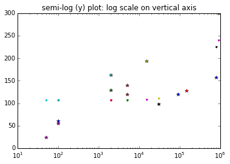

```python
eq =c_0+c_1*xdata
figure('linear-log')
title('semi-log (y) plot: log scale on vertical axis')
semilogx(xdata,ydata, '*',xdata,eq, '.-')
plt.show()
```

### b)

For power law fitting, it is easier to change variables. We will define $u_k=ln(x_k)$ and $v_k=ln(y_k)$. Then we will have $v_k = c_0 + c_1u_k$ where $c_0 = ln(A)$ and $c_1=p$.

```python
u = np.log(xdata)
v = np.log(ydata)
A = np.matrix(np.zeros((13,2)))
A[:,0] = np.ones((13,1))
A[:,1] = u.T
print("The matrix A is \n",A)
b = np.matrix(np.zeros((13,1)))
b[:,0] = v.T
print("The matrix b is \n",b)
```

```
The matrix A is
 [[  1.          13.59236701]
 [  1.           7.60090246]
 [  1.           8.51719319]
 [  1.           7.60090246]
 [  1.           3.91202301]
 [  1.          13.71015004]
 [  1.          10.30895266]
 [  1.           4.60517019]
 [  1.          11.40756495]
 [  1.           8.51719319]
 [  1.          11.91839057]
 [  1.           4.60517019]
 [  1.           9.61580548]]
The matrix b is
 [[ 5.05624581]
 [ 4.8598124 ]
 [ 4.78749174]
 [ 5.08759634]
 [ 3.17805383]
 [ 5.70378247]
 [ 4.58496748]
 [ 4.09434456]
 [ 4.78749174]
 [ 4.94164242]
 [ 4.85203026]
 [ 4.00733319]
 [ 5.26269019]]
```

Once again we have our normal equations:

```python
ATA = A.T.dot(A)
ATb = A.T.dot(b)
print("ATA is the matrix \n",ATA)
print("ATb is the matrix \n",ATb)
```

```
ATA is the matrix
 [[   13.           115.91178539]
 [  115.91178539  1161.99115194]]
ATb is the matrix
 [[  61.20348244]
 [ 565.45571815]]
```

And again by using built in functinos we can solve for ln(P) and a.

```python
ATA_inverse = ATA.I
sol = ATA_inverse.dot(ATb)
P = e**sol[0,0]
a = sol[1,0]
print("P is",P)
print("a is",a)
```

```
P is 28.1512539951
a is 0.153692635055
```

```python
x = np.linalg.solve(ATA,ATb)
print("Using the numpy solve function we get")
print(x)
```

```
Using the numpy solve function we get
[[ 3.3375919 ]
 [ 0.15369264]]
```

Therefore our power law model is $ y = 28.1512539951x^{0.153692635055}$

```
<function matplotlib.pyplot.show>
```

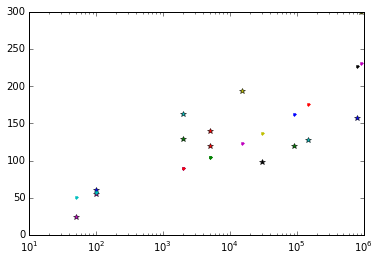

```python
eqn = P*np.array(xdata)**a
plt.semilogx(xdata,ydata,marker="*")
plt.semilogx(xdata,eqn,".")
plt.show
```